# Hospital Readmission Case Study

```python
# models for readmission prediction
seed = 42
model_lr = LogisticRegression()
model_gb = GradientBoostingClassifier(random_state=seed)
model_clf = RandomForestClassifier(random_state=seed)
model_dt = DecisionTreeClassifier(random_state=seed)
model_ada = AdaBoostClassifier(random_state=seed)

model_list = [model_lr, model_gb, model_clf, model_dt, model_ada]
model_name = ['lr', 'gb', 'clf', 'dt', 'ada']
model_name_pr = ['lr_pr', 'gb_pr', 'clf_pr', 'dt_pr', 'ada_pr']

pred_log, model_dict, results_df = evaluate_model_classifer(
    model_list, model_name, X_train_trans, y_train, X_test_trans, y_test
)
print()

pred_log_pr, model_dict_pr, results_df_pr = evaluate_model_classifer(
    model_list, model_name_pr, X_train_trans_processed, y_train_processed, X_test_trans_processed, y_test_processed
)
```

```
Name  Accuracy  Precision  Recall  F1 score  ROC_AUC          Confusion_Matrix
  lr    0.6120     0.6135  0.4049    0.4879   0.5954 [[1068, 291], [679, 462]]
  gb    0.6164     0.6201  0.4119    0.4950   0.6000 [[1071, 288], [671, 470]]
 clf    0.6020     0.5768  0.4803    0.5242   0.5922  [[957, 402], [593, 548]]
  dt    0.5332     0.4892  0.5171    0.5028   0.5319  [[743, 616], [551, 590]]
 ada    0.6064     0.5992  0.4154    0.4907   0.5911 [[1042, 317], [667, 474]]

  Name  Accuracy  Precision  Recall  F1 score  ROC_AUC          Confusion_Matrix
 lr_pr    0.6096     0.5920  0.4654    0.5211   0.5980  [[993, 366], [610, 531]]
 gb_pr    0.6136     0.6000  0.4601    0.5208   0.6013 [[1009, 350], [616, 525]]
clf_pr    0.5948     0.5626  0.5039    0.5317   0.5875  [[912, 447], [566, 575]]
 dt_pr    0.5332     0.4892  0.5153    0.5019   0.5318  [[745, 614], [553, 588]]
ada_pr    0.6040     0.5816  0.4715    0.5208   0.5934  [[972, 387], [603, 538]]
```

Processing the dataset to correct for skewness if not affecting the performance in any significant way. However, the overall F1 score and recall of the models trained on processed dataset is higher, hence proceeding for hyperparameter tuning on processed dataset.

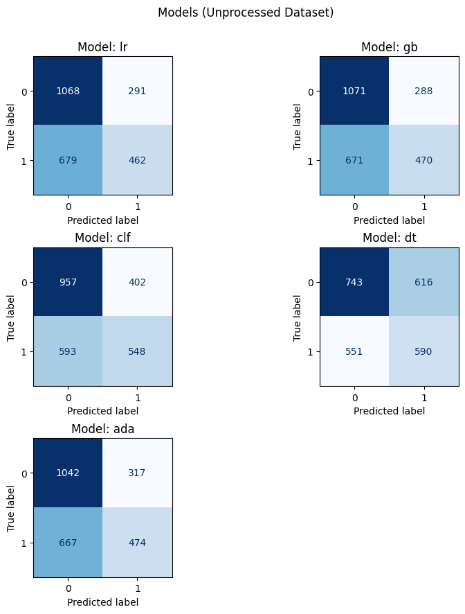

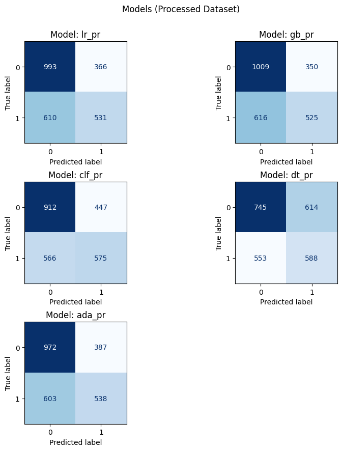

```python
def plot_cm(results_df, n_cols, plot_super_title):
    n_models = len(results_df)
    n_rows = math.ceil(n_models / n_cols)

    fig, axes = plt.subplots(n_rows, n_cols, figsize=(9, 3 * n_rows))  # adjust width & height
    axes = axes.flatten()  # flatten in case of multiple rows

    for i, (_, row) in enumerate(results_df.iterrows()):
        name = row['Name']
        cm = row['Confusion_Matrix']

        disp = ConfusionMatrixDisplay(confusion_matrix=cm, display_labels=[0, 1])
        disp.plot(ax=axes[i], cmap="Blues", values_format="d", colorbar=False)
        axes[i].set_title(f'Model: {name}')

    # Hide any unused subplots if models < n_cols * n_rows
    for j in range(i+1, len(axes)):
        fig.delaxes(axes[j])

    fig.tight_layout()
    fig.subplots_adjust(top=0.9)
    fig.suptitle(plot_super_title)
    plt.show()

plot_cm(results_df, 2, 'Models (Unprocessed Dataset)')
print()
plot_cm(results_df_pr, 2, 'Models (Processed Dataset)')
```

[figure not shown]

[figure not shown]

```python
roc_auc_display(pred_log, model_name)
print()
roc_auc_display(pred_log_pr, model_name_pr)
```

### Hyperparameter Tuning

```python
seed = 42
lr = LogisticRegression(tol=1e-4, max_iter=1000, random_state=seed)

space = dict(C=uniform(loc=0, scale=5),
                     penalty=['l2', 'l1'],
                     solver= ['liblinear'])

search = RandomizedSearchCV(lr,
                         space,
                         random_state=seed,
                         cv = 5,
                         scoring='f1')

rand_search = search.fit(X_train, y_train)
print('Best Hyperparameters: %s' % rand_search.best_params_)

params = rand_search.best_params_
lr = LogisticRegression(**params)
lr.fit(X_train_trans_processed, y_train)
print(classification_report(y_test, lr.predict(X_test_processed)))
```

```
Best Hyperparameters: {'C': 0.917173949330819, 'penalty': 'l1', 'solver': 'liblinear'}
              precision    recall  f1-score   support

           0       0.00      0.00      0.00      1359
           1       0.46      1.00      0.63      1141

    accuracy                           0.46      2500
   macro avg       0.23      0.50      0.31      2500
weighted avg       0.21      0.46      0.29      2500
```

```python
# Models
seed=42
model_lr  = LogisticRegression(random_state=seed, max_iter=2000)
model_gb  = GradientBoostingClassifier(random_state=seed)
model_clf = RandomForestClassifier(random_state=seed)
model_dt  = DecisionTreeClassifier(random_state=seed)
model_ada = AdaBoostClassifier(random_state=seed)

# Common CV setup
cv = StratifiedKFold(n_splits=5, shuffle=True, random_state=seed)
scoring = 'f1'

# Pipelines
pipe_lr  = Pipeline([('scaler', StandardScaler()), ('clf', model_lr)])
pipe_gb  = Pipeline([('scaler', StandardScaler()), ('clf', model_gb)])
pipe_rf  = Pipeline([('scaler', StandardScaler()), ('clf', model_clf)])
pipe_dt  = Pipeline([('scaler', StandardScaler()), ('clf', model_dt)])
pipe_ada = Pipeline([('scaler', StandardScaler()), ('clf', model_ada)])

# Parameter grids
param_grids = {
    'lr': {
        'clf__penalty': ['l1', 'l2'],
        'clf__C': [0.01, 0.1, 1.0, 10.0],
        'clf__solver': ['saga'],
        'clf__max_iter': [2000]
    },
    'gb': {
        'clf__n_estimators': [100, 300],
        'clf__learning_rate': [0.01, 0.05, 0.1],
        'clf__max_depth': [3, 5],
        'clf__subsample': [0.6, 0.8, 1.0],
        'clf__min_samples_split': [2, 5]
    },
    'rf': {
        'clf__n_estimators': [100, 300],
        'clf__max_depth': [None, 10, 20],
        'clf__min_samples_split': [2, 5],
        'clf__max_features': ['sqrt', 'log2', 0.3]
    },
    'dt': {
        'clf__criterion': ['gini', 'entropy'],
        'clf__max_depth': [None, 5, 10, 20],
        'clf__min_samples_split': [2, 5, 10],
        'clf__min_samples_leaf': [1, 2, 5]
    },
    'ada': {
        'clf__n_estimators': [50, 100, 200],
        'clf__learning_rate': [0.01, 0.1, 1.0],
        'clf__algorithm': ['SAMME.R', 'SAMME']
    }
}

# Mapping pipelines
pipes = {
    'lr': pipe_lr,
    'gb': pipe_gb,
    'rf': pipe_rf,
    'dt': pipe_dt,
    'ada': pipe_ada
}

# Run GridSearchCV for each model and collect results
results_tuned = []
for name in ['lr', 'gb', 'rf', 'dt', 'ada']:
    print(f"\nRunning GridSearch for: {name}")
    grid = GridSearchCV(
        estimator=pipes[name],
        param_grid=param_grids[name],
        scoring=scoring,
        cv=cv,
        n_jobs=-1,
        verbose=0,
        return_train_score=False
    )
    grid.fit(X_train_trans_processed, y_train)
    best = grid.best_estimator_
    best_params = grid.best_params_
    best_score = grid.best_score_
    print(f"Best {scoring} for {name}: {best_score:.4f}")
    print("Best params:", best_params)

    results_tuned.append({
        'model': name,
        'best_score': best_score,
        'best_params': best_params,
        'best_estimator': best
    })

# Convert to DataFrame for a quick summary
results_df_tuned = pd.DataFrame(results_tuned).sort_values('best_score', ascending=False)
results_df_tuned
```

```
Running GridSearch for: lr
Best f1 for lr: 0.5280
Best params: {'clf__C': 1.0, 'clf__max_iter': 2000, 'clf__penalty': 'l2', 'clf__solver': 'saga'}

Running GridSearch for: gb
Best f1 for gb: 0.5501
Best params: {'clf__learning_rate': 0.05, 'clf__max_depth': 5, 'clf__min_samples_split': 2, 'clf__n_estimators': 300, 'clf__subsample': 0.6}

Running GridSearch for: rf
Best f1 for rf: 0.5629
Best params: {'clf__max_depth': None, 'clf__max_features': 'sqrt', 'clf__min_samples_split': 2, 'clf__n_estimators': 300}

Running GridSearch for: dt
Best f1 for dt: 0.5191
Best params: {'clf__criterion': 'entropy', 'clf__max_depth': 10, 'clf__min_samples_leaf': 5, 'clf__min_samples_split': 2}

Running GridSearch for: ada
```

[output not shown]

[output cut: 35 more lines]

[output not shown]

```
Best f1 for ada: 0.5231
Best params: {'clf__algorithm': 'SAMME', 'clf__learning_rate': 1.0, 'clf__n_estimators': 100}
```

|  | model | best_score | best_params | best_estimator |
| --- | --- | --- | --- | --- |
| 2 | rf | 0.562919 | {'clf__max_depth': None, 'clf__max_features': 'sqrt', 'clf__min_samples_split': 2, 'clf__n_estim... | (StandardScaler(), (DecisionTreeClassifier(max_features='sqrt', random_state=1608637542), Decisi... |
| 1 | gb | 0.550065 | {'clf__learning_rate': 0.05, 'clf__max_depth': 5, 'clf__min_samples_split': 2, 'clf__n_estimator... | (StandardScaler(), ([DecisionTreeRegressor(criterion='friedman_mse', max_depth=5,\n ... |
| 0 | lr | 0.528001 | {'clf__C': 1.0, 'clf__max_iter': 2000, 'clf__penalty': 'l2', 'clf__solver': 'saga'} | (StandardScaler(), LogisticRegression(max_iter=2000, random_state=42, solver='saga')) |
| 4 | ada | 0.523070 | {'clf__algorithm': 'SAMME', 'clf__learning_rate': 1.0, 'clf__n_estimators': 100} | (StandardScaler(), (DecisionTreeClassifier(max_depth=1, random_state=1608637542), DecisionTreeCl... |
| 3 | dt | 0.519150 | {'clf__criterion': 'entropy', 'clf__max_depth': 10, 'clf__min_samples_leaf': 5, 'clf__min_sample... | (StandardScaler(), DecisionTreeClassifier(criterion='entropy', max_depth=10, min_samples_leaf=5,... |

```python
best_pipelines = {r['model']: r['best_estimator'] for r in results_tuned}

model_list = [
    best_pipelines['lr'],
    best_pipelines['gb'],
    best_pipelines['rf'],
    best_pipelines['dt'],
    best_pipelines['ada']
]
model_name = ['lr_tuned', 'gb_tuned', 'clf_tuned', 'dt_tuned', 'ada_tuned']

pred_log_tuned, model_dict_tuned, results_df_tuned = evaluate_model_classifer(
    model_list, model_name, X_train_trans_processed, y_train_processed, X_test_trans_processed, y_test_processed
)
```

```
     Name  Accuracy  Precision  Recall  F1 score  ROC_AUC         Confusion_Matrix
 lr_tuned    0.6096     0.5920  0.4654    0.5211   0.5980 [[993, 366], [610, 531]]
 gb_tuned    0.6236     0.6027  0.5145    0.5551   0.6148 [[972, 387], [554, 587]]
clf_tuned    0.6020     0.5706  0.5171    0.5425   0.5952 [[915, 444], [551, 590]]
 dt_tuned    0.5836     0.5504  0.4785    0.5120   0.5752 [[913, 446], [595, 546]]
ada_tuned    0.6068     0.5859  0.4724    0.5230   0.5960 [[978, 381], [602, 539]]
```

[figure not shown]

```python
plot_cm(results_df_pr, 3, 'Models (Hyperparameter Tuned)')
```

[figure not shown]

```python
roc_auc_display(pred_log_tuned, ['lr_tuned', 'gb_tuned', 'clf_tuned', 'dt_tuned', 'ada_tuned'])
```

```python
# Feature importance
print("Feature importance (Logistic Regression) (Coefficient and Odds Ratio):: ")

# Coefficients and Odds Ratios
log_reg = best_pipelines['lr'].named_steps['clf']
coefficients = log_reg.coef_[0]
odds_ratios = np.exp(coefficients)

feature_importance = pd.DataFrame({
    'Feature': X.columns,
    'Coefficient': coefficients,
    'Odds Ratio': odds_ratios
})
print(feature_importance.sort_values(by='Coefficient', ascending=False))
```

```
Feature importance (Logistic Regression) (Coefficient and Odds Ratio)::
              Feature  Coefficient  Odds Ratio
3        n_procedures     0.330980    1.392332
1    time_in_hospital     0.280817    1.324211
4       n_medications     0.200812    1.222395
0                 age     0.177896    1.194701
5        n_outpatient     0.147357    1.158767
2    n_lab_procedures     0.086154    1.089974
12       glucose_test     0.056940    1.058592
14             change     0.038906    1.039672
13            A1Ctest     0.012011    1.012083
15       diabetes_med     0.008468    1.008504
8   medical_specialty     0.002118    1.002120
10             diag_2    -0.015176    0.984938
7         n_emergency    -0.050506    0.950748
9              diag_1    -0.072368    0.930188
6         n_inpatient    -0.072618    0.929956
11             diag_3    -0.105117    0.900219
```

```
Feature importance (Random Forest) (Coefficient and Odds Ratio)::
```

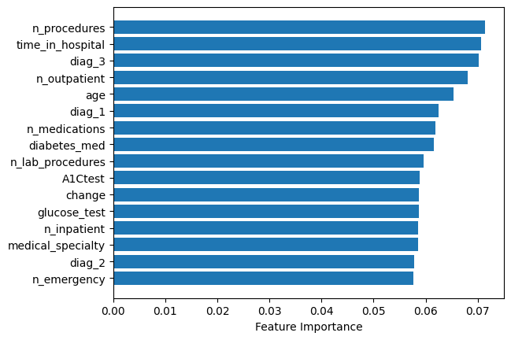

```python
# Feature importance
print("Feature importance (Random Forest) (Coefficient and Odds Ratio):: ")
clf = best_pipelines['rf'].named_steps['clf']
importances = clf.feature_importances_
feature_names = X.columns
sorted_idx = importances.argsort()

plt.barh(range(len(importances)), importances[sorted_idx])
plt.yticks(range(len(importances)), feature_names[sorted_idx])
plt.xlabel("Feature Importance")
plt.show()
```

```python
importances = clf.feature_importances_
feature_names = X.columns
for i in range(len(feature_names)):
    print(f"{feature_names[i]} : {importances[i]}")
```

```
age : 0.06543477986033111
time_in_hospital : 0.0706029400539916
n_lab_procedures : 0.059558450810273354
n_procedures : 0.07145417428242885
n_medications : 0.061888537902753775
n_outpatient : 0.06803925523030398
n_inpatient : 0.058621728562216084
n_emergency : 0.057604907907453415
medical_specialty : 0.05852173206154494
diag_1 : 0.06244013867991918
diag_2 : 0.057762515060332344
diag_3 : 0.07018356165118397
glucose_test : 0.05866969721755237
A1Ctest : 0.05889899872779137
change : 0.05878620956015825
diabetes_med : 0.061532372431765424
```

The following observations can be made from the above graph:

- Patients undergoing more procedures are at higher risk.
- Longer hospital stays indicate complexity or comorbidity.
- Specific diagnosis codes impact readmission risk.
- Older patients are more likely to be readmitted.
- Frequent outpatient visits may indicate underlying health issues.

## Model for Predicting the Length of Stay

The following models were used for the regression task to predict the length of hospital stay:

- **Linear Regression:** A foundational statistical model that predicts a continuous outcome based on a linear relationship with the input features.
- **Decision Tree Regressor:** A model that partitions the data based on feature values to predict a continuous outcome. It's similar to its classification counterpart but is used for regression tasks.
- **Random Forest Regressor:** An ensemble model that aggregates the predictions of multiple decision trees to improve accuracy and generalization for regression problems.
- **Gradient Boosting Regressor:** A powerful ensemble technique for regression that sequentially builds models to correct the errors of previous models.
- **AdaBoost Regressor:** An ensemble method that combines multiple weak regressors to create a strong predictor, with a focus on improving performance on difficult samples.

Performance Metrics:

- Mean Absolute Error
- Mean Absolute Error (After Rounding off predictions)
- Mean Squared Error
- Root Mean Squared Error
- R2 Score

```python
df_log.head()
```

|  | age | time_in_hospital | n_lab_procedures | n_procedures | n_medications | n_outpatient | n_inpatient | n_emergency | medical_specialty | diag_1 | diag_2 | diag_3 | glucose_test | A1Ctest | change | diabetes_med | readmitted |
| --- | --- | --- | --- | --- | --- | --- | --- | --- | --- | --- | --- | --- | --- | --- | --- | --- | --- |
| 0 | 1.386294 | 2.197225 | 4.290459 | 0.693147 | 2.944439 | 1.098612 | 0.0 | 0.0 | 1.609438 | 0.00000 | 2.079442 | 1.945910 | 0.0 | 0.0 | 0.000000 | 0.693147 | 0 |
| 1 | 1.386294 | 1.386294 | 3.555348 | 1.098612 | 2.639057 | 0.000000 | 0.0 | 0.0 | 1.791759 | 1.94591 | 1.945910 | 1.945910 | 0.0 | 0.0 | 0.000000 | 0.693147 | 0 |
| 2 | 0.693147 | 1.791759 | 3.828641 | 0.000000 | 2.944439 | 0.000000 | 0.0 | 0.0 | 1.609438 | 0.00000 | 0.000000 | 0.000000 | 0.0 | 0.0 | 0.693147 | 0.693147 | 1 |
| 3 | 1.386294 | 1.098612 | 3.610918 | 0.000000 | 2.564949 | 0.693147 | 0.0 | 0.0 | 1.609438 | 0.00000 | 1.945910 | 0.693147 | 0.0 | 0.0 | 0.693147 | 0.693147 | 1 |
| 4 | 1.098612 | 0.693147 | 3.761200 | 0.000000 | 2.079442 | 0.000000 | 0.0 | 0.0 | 1.386294 | 1.94591 | 0.000000 | 2.079442 | 0.0 | 0.0 | 0.000000 | 0.693147 | 0 |

```python
# Features from your transformed dataset
X_pd = df_sqrt.drop(columns=['readmitted', 'time_in_hospital'], axis=1)  # drop old classification + target
y_pd = df['time_in_hospital']  # use original target

X_train_pd, X_test_pd, y_train_pd, y_test_pd = train_test_split(X_pd, y_pd, test_size=0.10, random_state=42)

X_train_pd.shape, X_test_pd.shape
```

```
((22500, 15), (2500, 15))
```

```python
seed = 42

# pipeline
pipe_lr_pd = Pipeline([('scaler', StandardScaler()), ('reg', LinearRegression())])
pipe_gbr_pd = Pipeline([('reg', GradientBoostingRegressor(random_state=seed))])
pipe_rf_pd = Pipeline([('reg', RandomForestRegressor(random_state=seed))])
pipe_dt_pd = Pipeline([('reg', DecisionTreeRegressor(random_state=seed))])
pipe_ada_pd = Pipeline([('reg', AdaBoostRegressor(random_state=seed))])

pipeline_dict_pd = {
    'lr': pipe_lr_pd,
    'gbr': pipe_gbr_pd,
    'rf': pipe_rf_pd,
    'dt': pipe_dt_pd,
    'ada': pipe_ada_pd
}

# paramter grid
param_grids_pd = {
    'lr': {
    },
    'gbr': {
        'reg__n_estimators': [100, 300],
        'reg__learning_rate': [0.01, 0.05, 0.1],
        'reg__max_depth': [3, 5],
        'reg__subsample': [0.6, 0.8, 1.0]
    },
    'rf': {
        'reg__n_estimators': [100, 300],
        'reg__max_depth': [None, 10, 20],
        'reg__min_samples_split': [2, 5],
        'reg__max_features': ['sqrt', 0.3]
    },
    'dt': {
        'reg__max_depth': [None, 5, 10, 20],
        'reg__min_samples_split': [2, 5, 10],
        'reg__min_samples_leaf': [1, 2, 4]
    },
    'ada': {
        'reg__n_estimators': [50, 100, 200],
        'reg__learning_rate': [0.01, 0.1, 1.0]

    }
}

# CV
cv_pd = KFold(n_splits=5, shuffle=True, random_state=seed)
scoring_pd = 'neg_mean_absolute_error'

results_pd = []
for name, pipe in pipeline_dict_pd.items():
    print(f"\n=== Grid search for {name} ===")
    grid = GridSearchCV(
        estimator=pipe,
        param_grid=param_grids_pd.get(name, {}),
        scoring=scoring_pd,
        cv=cv_pd,
        n_jobs=-1,
        verbose=0,
        refit=True
    )

    grid.fit(X_train_pd, y_train_pd)

    best = grid.best_estimator_
    best_params = grid.best_params_
    best_cv_mae = -grid.best_score_

    # Evaluate on test set
    y_pred = best.predict(X_test_pd)
    test_mae = mean_absolute_error(y_test_pd, y_pred)
    test_mse = mean_squared_error(y_test_pd, y_pred)
    test_rmse = np.sqrt(test_mse)
    test_r2 = r2_score(y_test_pd, y_pred)

    # Rounded/clipped predictions for integer day error
    y_pred_rounded = np.clip(np.round(y_pred), 1, 14).astype(int)
    test_mae_rounded = mean_absolute_error(y_test_pd, y_pred_rounded)

    print(f"Best CV MAE: {best_cv_mae:.4f}")
    print("Best params:", best_params)
    print(f"Test MAE (raw preds): {test_mae:.4f}")
    print(f"Test MAE (rounded & clipped to 1-14): {test_mae_rounded:.4f}")
    print(f"Test MSE: {test_mse} \nTest RMSE: {test_rmse:.4f} \nTest R2: {test_r2:.4f}\n")

    results_pd.append({
        'model': name,
        'best_params': best_params,
        'cv_mae': best_cv_mae,
        'test_mae': test_mae,
        'test_mae_rounded': test_mae_rounded,
        'test_mse': test_mse,
        'test_rmse': test_rmse,
        'test_r2': test_r2,
        'estimator': best
    })

summary_pd = pd.DataFrame(results_pd).sort_values('test_mae')
print("\n===== Summary (sorted by test MAE) =====")
print(summary_pd[['model','cv_mae','test_mae','test_mae_rounded','test_rmse','test_r2']])
```

```
=== Grid search for lr ===
Best CV MAE: 1.9699
Best params: {}
Test MAE (raw preds): 1.9607
Test MAE (rounded & clipped to 1-14): 1.9328
Test MSE: 6.506078728061827
Test RMSE: 2.5507
Test R2: 0.2587


=== Grid search for gbr ===
Best CV MAE: 1.8292
Best params: {'reg__learning_rate': 0.05, 'reg__max_depth': 5, 'reg__n_estimators': 300, 'reg__subsample': 0.6}
Test MAE (raw preds): 1.8267
Test MAE (rounded & clipped to 1-14): 1.8136
Test MSE: 5.81850094244545
Test RMSE: 2.4122
Test R2: 0.3371


=== Grid search for rf ===
Best CV MAE: 1.8705
Best params: {'reg__max_depth': 20, 'reg__max_features': 0.3, 'reg__min_samples_split': 5, 'reg__n_estimators': 300}
Test MAE (raw preds): 1.8593
Test MAE (rounded & clipped to 1-14): 1.8368
Test MSE: 5.945861157843448
Test RMSE: 2.4384
Test R2: 0.3226


=== Grid search for dt ===
Best CV MAE: 1.9681
Best params: {'reg__max_depth': 5, 'reg__min_samples_leaf': 4, 'reg__min_samples_split': 2}
Test MAE (raw preds): 1.9466
Test MAE (rounded & clipped to 1-14): 1.9584
Test MSE: 6.5047273042320715
Test RMSE: 2.5504
Test R2: 0.2589


=== Grid search for ada ===
Best CV MAE: 2.0069
Best params: {'reg__learning_rate': 0.01, 'reg__n_estimators': 50}
Test MAE (raw preds): 1.9761
Test MAE (rounded & clipped to 1-14): 1.9744
Test MSE: 6.629451760719629
Test RMSE: 2.5748
Test R2: 0.2447


===== Summary (sorted by test MAE) =====
  model    cv_mae  test_mae  test_mae_rounded  test_rmse   test_r2
1   gbr  1.829239  1.826706            1.8136   2.412157  0.337080
2    rf  1.870481  1.859267            1.8368   2.438414  0.322569
3    dt  1.968051  1.946614            1.9584   2.550437  0.258896
0    lr  1.969946  1.960656            1.9328   2.550702  0.258742
4   ada  2.006893  1.976067            1.9744   2.574772  0.244686
```

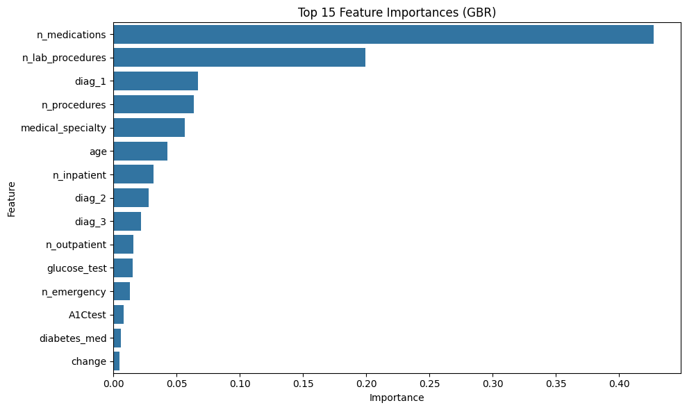

```python
# feature importance
gbr_model = summary_pd.loc[summary_pd['model'] == 'gbr', 'estimator'].values[0]
gbr_reg = gbr_model.named_steps['reg']

feature_importances = pd.DataFrame({
    'Feature': X_train_pd.columns,
    'Importance': gbr_reg.feature_importances_
})

feature_importances = feature_importances.sort_values(by='Importance', ascending=False)

# Plot feature importances
plt.figure(figsize=(10,6))
sns.barplot(x='Importance', y='Feature', data=feature_importances)
plt.title('Top 15 Feature Importances (GBR)')
plt.xlabel('Importance')
plt.ylabel('Feature')
plt.tight_layout()
plt.show()
```

```python
feature_importances
```

|  | Feature | Importance |
| --- | --- | --- |
| 3 | n_medications | 0.427435 |
| 1 | n_lab_procedures | 0.199480 |
| 8 | diag_1 | 0.066956 |
| 2 | n_procedures | 0.063471 |
| 7 | medical_specialty | 0.056438 |
| 0 | age | 0.042415 |
| 5 | n_inpatient | 0.031486 |
| 9 | diag_2 | 0.028017 |
| 10 | diag_3 | 0.021760 |
| 4 | n_outpatient | 0.015759 |
| 11 | glucose_test | 0.015166 |
| 6 | n_emergency | 0.012868 |
| 12 | A1Ctest | 0.007949 |
| 14 | diabetes_med | 0.005963 |
| 13 | change | 0.004837 |

Observations drawn from the graph

- Most important predictors:
  - n_medications (number of medications)
  - n_lab_procedures (number of lab tests)
  - These dominate the prediction of hospital stay length, suggesting more treatments and lab investigations correlate with longer stays.
- Moderately important predictors:
  - diag_1 (primary diagnosis)
  - n_procedures (number of procedures)
  - medical_specialty (specialty of the admitting physician)
  - These show that the type of illness and medical care also significantly affect hospital stay.
- Smaller contributions:
  - age
  - n_inpatient, n_outpatient, n_emergency (prior healthcare visits)
  - Patient demographics and past healthcare utilization have some impact, but less than treatment intensity.
- Least important predictors:
  - A1Ctest, glucose_test
  - change (change in diabetes medication)
  - diabetes_med (whether diabetes medication prescribed)
  - Diabetes-specific measures contribute very little to predicting hospital stay length.
- Overall takeaway:
  - Intensity of care (medications, labs, procedures) is the main driver of hospital stay length.
  - Patient history and comorbidities play a secondary role.

## Anomaly Detection

The following models were used for anomaly detection to identify unusual patient cases:

- **One-Class SVM:** An unsupervised learning algorithm that is trained on a dataset with only one class of data (the "normal" data). The model learns to identify a boundary that separates the normal data points from any outliers or anomalies.
- **Isolation Forest:** An efficient algorithm that detects anomalies by isolating them from the rest of the data. It builds a forest of random trees and measures the number of splits required to isolate a data point. Anomalies, being few and different, are isolated in fewer steps.

Performance Metrics: Precision, Recall, F1 score

```python
# Features (exclude target)
X = df_features.drop(columns=['readmitted'])

# Standardize features
scaler = StandardScaler()
X_scaled = scaler.fit_transform(X)

# Target
y = df_features['readmitted']  # 1 = readmitted, 0 = normal
```

```python
# Assume 1 = anomaly (readmitted), -1 = normal
iso_forest = IsolationForest(contamination=y.mean(), random_state=42)  # contamination ~ proportion of anomalies
iso_forest.fit(X_scaled)

# Predict anomalies (-1 = normal, 1 = anomaly) -> map to 0/1
y_pred_iso = iso_forest.predict(X_scaled)
y_pred_iso = [1 if p == -1 else 0 for p in y_pred_iso]  # flip because IsolationForest marks outliers as -1

# Evaluate
precision_iso = precision_score(y, y_pred_iso)
recall_iso = recall_score(y, y_pred_iso)
f1_iso = f1_score(y, y_pred_iso)

print("Isolation Forest - Precision:", precision_iso)
print("Isolation Forest - Recall:", recall_iso)
print("Isolation Forest - F1-score:", f1_iso)
```

```
Isolation Forest - Precision: 0.5024672451931258
Isolation Forest - Recall: 0.5024672451931258
Isolation Forest - F1-score: 0.5024672451931258
```

```python
# Fit One-Class SVM on the majority class only (normal patients)
X_normal = X_scaled[y == 0]
oc_svm = OneClassSVM(nu=y.mean(), kernel='rbf', gamma='scale')
oc_svm.fit(X_normal)

# Predict anomalies (-1 = anomaly, 1 = normal)
y_pred_svm = oc_svm.predict(X_scaled)
y_pred_svm = [1 if p == -1 else 0 for p in y_pred_svm]  # map -1 -> anomaly

# Evaluate
precision_svm = precision_score(y, y_pred_svm)
recall_svm = recall_score(y, y_pred_svm)
f1_svm = f1_score(y, y_pred_svm)

print("One-Class SVM - Precision:", precision_svm)
print("One-Class SVM - Recall:", recall_svm)
print("One-Class SVM - F1-score:", f1_svm)
```

```
One-Class SVM - Precision: 0.4984300780935512
One-Class SVM - Recall: 0.5267143100221201
One-Class SVM - F1-score: 0.512182006204757
```

```python
# Hyperparameter grid
contamination = [y.mean(), 0.05, 0.1, 0.15]  # proportion of anomalies
n_estimators = [100, 300, 500]
max_samples = ['auto', 0.5, 0.75]
max_features = [1.0, 0.8, 0.5]

best_f1 = 0
best_params_iso = {}

for c in contamination:
    for n in n_estimators:
        for s in max_samples:
            for f in max_features:
                iso = IsolationForest(
                    n_estimators=n,
                    max_samples=s,
                    contamination=c,
                    max_features=f,
                    random_state=42
                )
                iso.fit(X_train)

                y_pred = iso.predict(X_test)
                y_pred = [1 if p == -1 else 0 for p in y_pred]  # convert -1 -> anomaly

                f1 = f1_score(y_test, y_pred)
                if f1 > best_f1:
                    best_f1 = f1
                    best_params_iso = {'n_estimators': n, 'max_samples': s, 'contamination': c, 'max_features': f}

print("Best Isolation Forest F1:", best_f1)
print("Best params:", best_params_iso)
```

```
Best Isolation Forest F1: 0.4976118106817195
Best params: {'n_estimators': 300, 'max_samples': 'auto', 'contamination': 0.47016, 'max_features': 1.0}
```

```python
# Hyperparameter grid
nus = [y.mean(), 0.05, 0.1, 0.15]  # expected anomaly proportion
gammas = ['scale', 'auto', 0.01, 0.05, 0.1]
kernels = ['rbf', 'poly', 'sigmoid']

best_f1_svm = 0
best_params_svm = {}

# Fit on majority class only (normal patients)
X_train_normal = X_scaled[y == 0]

for nu in nus:
    for gamma in gammas:
        for kernel in kernels:
            svm = OneClassSVM(nu=nu, kernel=kernel, gamma=gamma)
            svm.fit(X_train_normal)

            y_pred = svm.predict(X_scaled)
            y_pred = [1 if p == -1 else 0 for p in y_pred]  # -1 = anomaly

            f1 = f1_score(y, y_pred)
            if f1 > best_f1_svm:
                best_f1_svm = f1
                best_params_svm = {'nu': nu, 'gamma': gamma, 'kernel': kernel}

print("Best One-Class SVM F1:", best_f1_svm)
print("Best params:", best_params_svm)
```

```
Best One-Class SVM F1: 0.5306422618074849
Best params: {'nu': 0.47016, 'gamma': 0.05, 'kernel': 'sigmoid'}
```

```python
# Fit One-Class SVM on the majority class only (normal patients)
X_normal = X_scaled[y == 0]
oc_svm = OneClassSVM(nu=0.47016, kernel='sigmoid', gamma=0.05)
oc_svm.fit(X_normal)

# Predict anomalies (-1 = anomaly, 1 = normal)
y_pred_svm = oc_svm.predict(X_scaled)
y_pred_svm = [1 if p == -1 else 0 for p in y_pred_svm]  # map -1 -> anomaly

# Evaluate
precision_svm = precision_score(y, y_pred_svm)
recall_svm = recall_score(y, y_pred_svm)
f1_svm = f1_score(y, y_pred_svm)

print("One-Class SVM - Precision:", precision_svm)
print("One-Class SVM - Recall:", recall_svm)
print("One-Class SVM - F1-score:", f1_svm)
```

```
One-Class SVM - Precision: 0.5104543310800189
One-Class SVM - Recall: 0.5524927684192615
One-Class SVM - F1-score: 0.5306422618074849
```

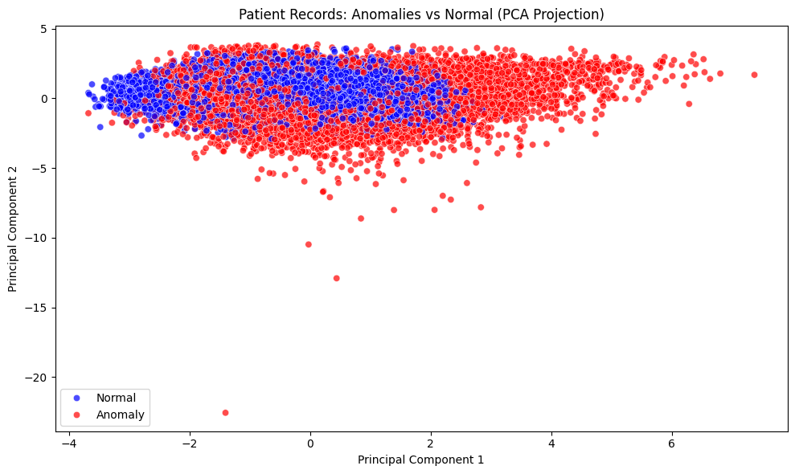

```python
# Anomaly plot
pca = PCA(n_components=2)
X_pca = pca.fit_transform(X_scaled)

# Create a DataFrame for plotting
df_plot = pd.DataFrame(X_pca, columns=['PC1', 'PC2'])
df_plot['Anomaly'] = y_pred_svm  # or y_pred_svm for One-Class SVM

# Map 0->Normal, 1->Anomaly
df_plot['Anomaly_Label'] = df_plot['Anomaly'].map({0:'Normal', 1:'Anomaly'})

plt.figure(figsize=(10,6))
sns.scatterplot(
    x='PC1', y='PC2',
    hue='Anomaly_Label',
    data=df_plot,
    palette={'Normal':'blue', 'Anomaly':'red'},
    alpha=0.7
)
plt.title("Patient Records: Anomalies vs Normal (PCA Projection)")
plt.xlabel("Principal Component 1")
plt.ylabel("Principal Component 2")
plt.legend()
plt.tight_layout()
plt.show()
```

## Recommended Strategies for Hospitals

1. Targeted Follow-Up Care
   - Who: High-risk patients based on model predictions (e.g., older patients, long stays, multiple procedures).
   - What: Post-discharge follow-up calls, home visits, telemedicine check-ins.
   - Impact: Early intervention can prevent complications, reducing readmissions.
2. Enhanced Discharge Planning
   - Ensure patients understand medications, wound care, and follow-up appointments.
   - Use predictive risk models to personalize discharge instructions.
   - Coordinate with primary care physicians for smooth transitions.
3. Medication Management
   - Review high-risk patients’ medications to reduce polypharmacy complications.
   - Provide education on adherence and potential side effects.
4. Specialty-Specific Interventions
   - Focus on patients in high-risk medical specialties (identified by medical_specialty and diagnosis codes).
   - Tailor care plans for chronic diseases like diabetes (A1C, glucose tests) or cardiovascular conditions.
5. Outpatient Care Coordination
   - Track patients with frequent outpatient visits (n_outpatient) and provide integrated care plans to reduce unnecessary admissions.

## Impact on Patient Outcomes and Hospital Efficiency

- Patient Outcomes
  - Lower readmissions -> fewer complications -> improved quality of life.
  - Personalized care reduces errors and improves adherence to treatment plans.
- Hospital Efficiency
  - Reduced readmissions -> lower costs and penalties under healthcare policies.
  - Optimized resource allocation (staffing, bed management, discharge planning).

## Challenges of Deploying ML in Healthcare

1. Data Privacy
   - Healthcare data is sensitive (HIPAA/GDPR).
   - Must anonymize data and use secure storage and transfer protocols.
2. Ethical Use
   - Predictions should aid, not replace, clinician judgment.
   - Risk of bias: older patients or minority groups may be flagged more frequently — models must be audited for fairness.
3. Integration
   - Models must integrate into existing EHR systems without disrupting workflow.
   - Clinicians need interpretable explanations (why the patient is high-risk).
4. Data Quality
   - Missing or inconsistent entries (diagnosis codes, lab results) can reduce model reliability.
   - Continuous monitoring and retraining are required.
5. Patient Communication
   - Explain interventions to patients clearly to ensure cooperation.
   - Avoid stigma from being labeled high-risk.

## Conclusions and Future Work

1. Data Privacy: Strict adherence to regulations like HIPAA.
2. Ethical Use: Ensuring the model is audited for bias and does not unfairly flag certain patient groups.
3. Integration: The model must be seamlessly integrated into existing EHR systems without disrupting workflow.
4. Patient Communication: Providing clear explanations to patients to ensure cooperation with post-discharge plans and avoid the stigma of being labeled as "high-risk."